# Overmodification Experiment 2: Static Colour vs. Orientation Free Response Paradigm

A processing script for experiment two of the overmodification project

*Set up computing environment*

```r
library(tidyverse)
library(jsonlite)
library(brms)
library(tidybayes)
library(BayesFactor)
library(ggthemr)
ggthemr("pale")


sand = c("#e0cda9")
dust = c("#9E8472")
forest = c("#a0ae9b")
shallowWaters = c("#a4b8c1")

darkSand = c("#5C4033")
darkDust = c("#1b0000")
darkForest = c("#06402B")
darkShallowWaters = c("#2f4858")

earthShades = c("#b2988e", "#b37a5f", "#d4b88a", "#a0ae9b", "#8d9da8")

earthShadesDark = c("#554740", "#553929", "#68553d", "#06402B", "#2f4858")

fourPalette = c("#7a6b6e", "#8d9da8", "#e0cda9", "#a8a89e")

fourPaletteDark = c("#1b0000", "#2f4858", "#5C4033", "#06402B")

threePalette = c("#8d9da8", "#a8a89e", "#e0cda9")

threePaletteDark = c("#2f4858", "#06402B", "#5C4033")

data <- read_csv("rawData/rawData.csv")

finishStatusOrient <- read_csv("rawData/finishStatuses/orientationFinishStatuses.csv")
finishStatusColor <- read_csv("rawData/finishStatuses/colorFinishStatuses.csv")

#for ease of col name use
colnames(data)<- c("serverCode", "column1", "column2", "string")
```

*Removing participants who did not complete the experiment (in-line with ethics approval), and experimenters debug link*

```r
# experimenters debugging
data <- data %>%
  select(-column1) %>%
  filter(!grepl('debug', serverCode)) %>%
  separate(
    serverCode,
    into = c("Participant id", NA),
    sep = ":",
    remove=FALSE
    )

# drop outs
finishStatus <- bind_rows(finishStatusOrient, finishStatusColor)

data <- finishStatus %>%
  select("Participant id", "Status") %>%
  left_join(data) %>%
  filter(Status == "APPROVED") %>%
  select(-`Participant id`, -Status)
```

*Indexing df for trial ordering:*

```r
indexedDataFrame <- data %>%
group_by(serverCode) %>%
mutate(index = row_number())
```

## Transforming JSON strings to nice tibbles

*Turn server codes into participants with id’s, and filter out unnecessary columns.*

```r
participantData <- indexedDataFrame %>%
  separate(serverCode,
           into = c("participant", NA),
           sep = ":",
           remove=FALSE) %>%
  group_by(participant) %>%
  mutate(participant = if(n() > 1) {
    sprintf("participant%03d",
            cur_group_id())
    }) %>%
  ungroup() %>%
  select(participant,
         index,
         everything(),
         -serverCode) %>%
  arrange(participant) %>%
  select(-column2)
```

*Check our total N, INCLUDING rejected and returned*

```r
usablePreEverything <- participantData$participant %>%
  unique()

message('Everything including rejections and returns: ', length(usablePreEverything), ' people.')
```

As expected, 40 participants.

*Filter in relevant data*

```r
data <- participantData %>%
  filter(str_detect(tolower(string), "setsize"))
```

*Parse*

```r
parseddata <- data %>%
  mutate(inx = 1:n()) %>%
  rowwise() %>%
  mutate(trialdata = lapply(string, fromJSON)) %>%
  unnest(trialdata) %>%
  mutate(label = names(trialdata)) %>%
  spread(label, trialdata) %>%
  unnest(where(is.list)) %>%
  select(-string, -inx)
```

*Check our total N recruited after filtering in relevant data*

```r
usableAfterFirstFilter <- parseddata$participant %>%
  unique()

message('Total recruited is: ', length(usableAfterFirstFilter), ' people.')
```

Again, N = 40.

## Participant Removal

*Filter in crit data*

```r
parsedCrit <- parseddata %>%
  filter(
    trialType == "crit"
  )
```

#### Failure to establish reference on >50% of trials

*Set up a dictionary of terms constituting sufficiency*

Note: set up sufficient terms by iterating over the next three chunks, expanding sufficient terms with manual checks to identify idiocyncratic responses/spelling.

Some notes:

- Some said “sole object of” or “only object with”. I accept these responses as sufficient.
- “Like a ball” – accept.
- “X sided or X pointed object” – accept.
- Responses that include colour but no noun are not considered sufficient. E.g., I’m marking “green” or “green one” is not sufficient (even though it technically is) – just to be conservative toward hypothesis.

```r
sufficientTerms <- c(
  "hexagon", "pentagon", "square", "circle", "sides", "corners", "round", "shape", "points", "pointed", "sided", "ball", "sole", "only", "polygon", "sqiare", "suqare", "Sqaure", "odd")
```

*Set function returning responses w/ a word in the dictionary*

```r
containsSufficientTerm <- function(text) {
  any(sapply(sufficientTerms, function(term) grepl(term, text, ignore.case = TRUE)))
}
```

*Run function on responses*

```r
noSufficientTerm <- parsedCrit[!sapply(
  parsedCrit$response,
  containsSufficientTerm), ]

 noSufficientTerm %>% select(response) %>% view()
```

After a manual check, I’m satisfied with what is included and excluded, so I’ll mutate the condition to a tibble.

*Mutate to TRUE/FALSE condition, Calc proportion*

```r
containsTermCheck <- parsedCrit %>%
  mutate(
    containsSufficientTerm = sapply(response,
                                    containsSufficientTerm)
    ) %>%
  group_by(participant) %>%
  summarise(
    totalTrials = n(),
    nonSufficientTrials = sum(containsSufficientTerm == FALSE),
    proportionNonSufficient =
      nonSufficientTrials / totalTrials
            )
```

*Remove identified participants (2)*

```r
nonSufficientParticipantsfilter <- containsTermCheck %>%
  filter(proportionNonSufficient >= 0.50)
```

*Apply to data frame*

```r
sufficientParsedCrit <- anti_join(
  parsedCrit,
  nonSufficientParticipantsfilter,
  by = "participant"
)
```

*Check N*

```r
usablesufficientParsedCrit <- sufficientParsedCrit$participant %>%
  unique()

message('Total providing >50% sufficient responses is: ', length(usablesufficientParsedCrit), ' people.')
```

2 participants removed due to that criteria.

**Trial Removal: Failure to establish reference**

*Count N-trials before*

```r
message('Total number of trials before independent trial remove is: ', nrow(sufficientParsedCrit), ' trials.')
```

Prior to removal, 1292 trials, N = 38.

*Identify non-sufficient responses*

```r
noSufficientTermTrials <- sufficientParsedCrit[!sapply(
  sufficientParsedCrit$response,
  containsSufficientTerm), ]

 noSufficientTermTrials
```

```
# A tibble: 15 × 7
   participant    index nDistract    redundant        response setSize trialType
   <chr>          <int> <chr>        <chr>            <chr>    <chr>   <chr>
 1 participant001    12 distractors0 colorRedundant   "green"  setSiz… crit
 2 participant002    20 distractors0 colorRedundant   "the bl… setSiz… crit
 3 participant002    21 distractors0 colorRedundant   "blue o… setSiz… crit
 4 participant002    24 distractors0 colorRedundant   "green … setSiz… crit
 5 participant002    43 distractors0 colorRedundant   "green … setSiz… crit
 6 participant002    50 distractors0 colorRedundant   "green … setSiz… crit
 7 participant009     5 distractors3 colorRedundant   "Click … setSiz… crit
 8 participant009    13 distractors0 colorRedundant   "Centra… setSiz… crit
 9 participant009    46 distractors1 colorRedundant   "Centra… setSiz… crit
10 participant028     4 distractors0 orientationRedu… "middle" setSiz… crit
11 participant028     6 distractors0 orientationRedu… "middle" setSiz… crit
12 participant028     7 distractors0 orientationRedu… "3,3"    setSiz… crit
13 participant028    13 distractors2 orientationRedu… "middle… setSiz… crit
14 participant031    11 distractors0 colorRedundant   "select… setSiz… crit
15 participant033    29 distractors0 colorRedundant   "blue"   setSiz… crit
```

After Manual checking, this proved adequate.

*Mutate to TRUE/FALSE condition, and remove fifteen trials above*

```r
sufficientParticipantAndTrialCrit <- sufficientParsedCrit %>%
  mutate(
    containsSufficientTerm = sapply(response,
                                    containsSufficientTerm)
    ) %>%
  filter(containsSufficientTerm == TRUE)
```

*Count N trials after*

```r
message('Total number of trials after non-sufficient trial remove is ', nrow(sufficientParticipantAndTrialCrit), '. The number of removed trials was ', nrow(sufficientParsedCrit) - nrow(sufficientParticipantAndTrialCrit), '. Percent trial removal == ', 15/nrow(sufficientParsedCrit), '.')
```

Total number of trials after non-sufficient trial remove is 1277. The number of removed trials was 15. Proportion trial removal == 0.01.

The only other point of removal is a demonstrable violation of task instructions. From manual checking, we can see that there was no violation in terms of writing random responses. However, we should also look at participants using spatial information.

### Inclusion of Spatial information on >50% of trials

*Set up dictionary to identify terms used*

```r
spatialTerms <- c(
  "left", "right", "above", "below", "top", "bottom", "row", "first", "second", "1st", "2nd", "3rd", "last", "middle", "furthest", "far", "next", "diagonally")
```

*Set function returning responses with a term in the dictionary*

```r
containsSpatialTerm <- function(text) {
  any(sapply(spatialTerms, function(term) grepl(term, text, ignore.case = TRUE)))
}
```

*Mutate to true/false condition*

```r
containsSpatialCheck <- sufficientParticipantAndTrialCrit %>%
  mutate(
    containsSpatialTerm = sapply(response,
                                    containsSpatialTerm)
    )
```

From manual checking, we can ignore participant009 (do not remove) — they’re using words like top to describe shape (‘pointed top’), not spatial position. All others are guilty as charged.

*Calc proportion*

```r
spatialCheckProp <- containsSpatialCheck %>%
  group_by(participant) %>%
  summarise(
    totalTrials = n(),
    spatialTrials = sum(containsSpatialTerm == TRUE),
    proportionSpatial =
      spatialTrials / totalTrials
            )
```

*Filter in those meeting removal criteria*

```r
SpatialParticipantsfilter <- spatialCheckProp %>%
  filter(proportionSpatial >= 0.50)
```

*Remove from working dataframe*

```r
sufficientAndNonSpatial <- anti_join(
  sufficientParticipantAndTrialCrit,
  SpatialParticipantsfilter,
  by = "participant"
)
```

Just one participant removed (005)

*Taking stock*

```r
usablesufficientAndNonSpatial <- sufficientAndNonSpatial$participant %>%
  unique()

message('Total after checking for >50% non-spatial responses is: ', length(usablesufficientAndNonSpatial), ' people.')
```

So we’re left with 37/40 people after completing participant removal.

**Trial Removal: Using spatial information non-systematically**

*Prior taking stock*

```r
message('Total number of trials before independent trial remove is: ', nrow(sufficientAndNonSpatial), ' trials.')
```

*Identify and remove spatial responses with new df*

```r
allTrialsAndSpatialCheck <- sufficientAndNonSpatial %>%
  mutate(
    containsSpatialTerm = sapply(response,
                                    containsSpatialTerm)
    ) %>%
  filter(containsSpatialTerm == FALSE)
```

*Post taking stock*

```r
message(
  'Total number of trials after independent trial remove is: ',
  nrow(allTrialsAndSpatialCheck),
  ' trials. The number of removed trials was ',
  nrow(sufficientAndNonSpatial) -
    nrow(allTrialsAndSpatialCheck),
  '. Percent trial removal == ',
  38/(nrow(sufficientParsedCrit))
  )
```

Total number of trials after this trial removal is: 1205 trials. The number of removed trials was 38. Total proportion trial removal == 0.03

## Building the Final Tibble

*Create filler dictionary*

```r
filler_words <- c("the", "a", "an", "one", "it", "is", "was", "that", "this", "there", "with", "not", "the", "only", "last", "Lines", "stripes", "lines", "sided", "sides", "called", "has", "this", "a", "has", "shape", "figure", "corners", "corner", "pointy", "top", "flat", "bottom", "and", "pointed", "the", "item", "below", "above", "to", "left", "right", "odd", "out", "color", "colour", "of", "only", "type")
```

*Create overinformativeness column*

```r
process_response <- function(response) {
  words <- str_split(tolower(response), "\\s+")[[1]]
  non_filler_count <- sum(!words %in% filler_words & words != "")
  return(non_filler_count)
}

tibble <- allTrialsAndSpatialCheck %>%
  select(-containsSufficientTerm, -containsSpatialTerm) %>%
  mutate(across(where(is.character), tolower)) %>%
  rowwise() %>%
  mutate(
    non_filler_count = process_response(response),
    overinformative = non_filler_count > 1
  ) %>%
  select(-non_filler_count) %>%
  ungroup()
```

We now have to manually check. I’ve done so, iterating the filler words dictionary on each identification of mis-spelling/idiosyncracy.

*Manual Check*

```r
tibble %>%
  select(overinformative, response) %>% view()
```

*Rename for plotting and working with df*

```r
tibble <- tibble %>%
    mutate(setSize = recode(setSize, setsize3 = 'setsize03')) %>%
  mutate(setSize = recode(setSize, setsize6 = 'setsize06')) %>%
  mutate(setSize = recode(setSize, setsize9 = 'setsize09'))

labels <- c(
  "colorredundant" = "Colour Redundant",
  "orientationredundant" = "Orientation Redundant"
)
```

*Everything looks great. Save as df*

```r
write_csv(tibble, "processedData.csv")
```

## Whaddowegot?

*Colour vs. Orientation Redundant*

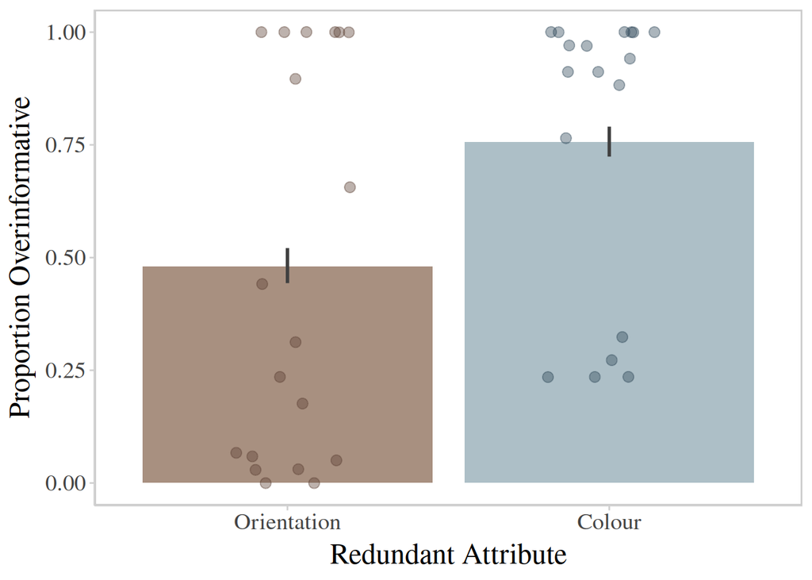

```r
tibble %>%
  filter(trialType == "crit") %>%
  mutate(od = ifelse(overinformative, 1, 0)) %>%
  ggplot(
    aes(x = redundant,
        y = od,
        fill = redundant,
        color = redundant)
    ) +
  stat_summary(fun.y = mean, geom="bar",
               alpha = 0.9, show.legend=FALSE,
               color = NA) +
  geom_jitter(
      stat = "summary", aes(group = participant),
      fun = mean, alpha = 0.4, size = 2.8,
      show.legend = FALSE, width = 0.2
      ) +
  stat_summary(fun.data = mean_cl_boot,
               geom="linerange", size = 1,
               color = "grey25") +
  coord_cartesian(ylim = c(0, 1)) +
  ylab("Proportion Overinformative") +
  xlab("Redundant Attribute") +
  theme(
    text = element_text(size = 18,
                        family = "serif",
                        color = "black"),
    panel.border = element_rect(color = "gray80",
                                fill = NA,
                                size = 1),
    panel.grid = element_blank()
    ) +
 scale_x_discrete(
    limits = c("orientationredundant", "colorredundant"),

    labels = c("Orientation",  "Colour")
 ) +
  scale_fill_manual(values = c(shallowWaters, dust)) +
  scale_color_manual(values = c(darkShallowWaters, darkSand))
```

*Comparison of set sizes, faceted by redundant attribute*

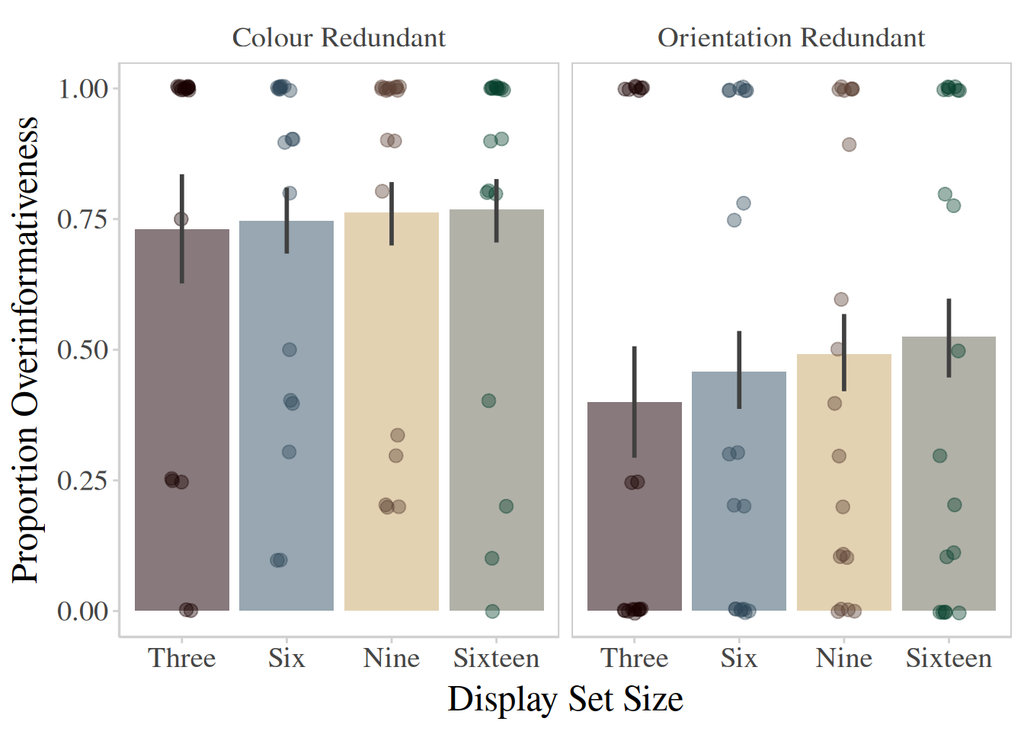

```r
tibble %>%
  mutate(od = ifelse(overinformative, 1, 0)) %>%
  filter(trialType == "crit") %>%
  ggplot(
    aes(x = setSize,
        y = od,
        fill = setSize,
        color = setSize)
    ) +
    facet_wrap(~redundant,
             labeller = as_labeller(labels)
               ) +
  stat_summary(fun.y = mean, geom="bar",
               alpha = 0.9, show.legend=FALSE,
               color = NA) +
  geom_jitter(
      stat = "summary", aes(group = participant),
      fun = mean, alpha = 0.4, size = 2.8,
      show.legend = FALSE, width = 0.1
      ) +
  stat_summary(fun.data = mean_cl_boot,
               geom="linerange", size = 1,
               color = "grey25") +
  coord_cartesian(ylim = c(0, 1)) +
  ylab("Proportion Overinformativeness") +
  xlab("Display Set Size") +
  theme(
    text = element_text(size = 18,
                        family = "serif",
                        color = "black"),
    panel.border = element_rect(color = "gray80",
                                fill = NA,
                                size = 0.7),
    panel.grid = element_blank()
    ) +
  scale_fill_manual(values = fourPalette
                    ) +
  scale_color_manual(values = fourPaletteDark
                     ) +
  scale_x_discrete(
    labels = c("Three", "Six", "Nine", "Sixteen")
    )
```

*Comparison of n-distractors, faceted by redundant attribute*

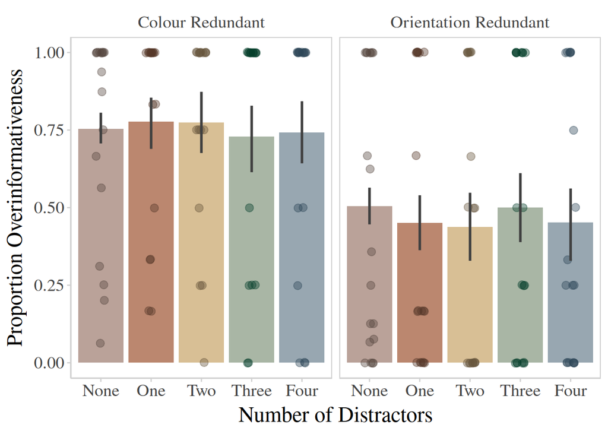

```r
tibble %>%
  mutate(od = ifelse(overinformative, 1, 0)) %>%
  filter(trialType == "crit") %>%
  ggplot(
    aes(x = nDistract,
        y = od,
        fill = nDistract,
        color = nDistract)
    ) +
    facet_wrap(~redundant,
             labeller = as_labeller(labels)
               ) +
  stat_summary(fun.y = mean, geom="bar",
               alpha = 0.9, show.legend=FALSE,
               color = NA) +
  geom_jitter(
      stat = "summary", aes(group = participant),
      fun = mean, alpha = 0.4, size = 2.8,
      show.legend = FALSE, width = 0.1
      ) +
  stat_summary(fun.data = mean_cl_boot,
               geom="linerange", size = 1,
               color = "grey25") +
  coord_cartesian(ylim = c(0, 1)) +
  ylab("Proportion Overinformativeness") +
  xlab("Number of Distractors") +
  theme(
    text = element_text(size = 18,
                        family = "serif",
                        color = "black"),
    panel.border = element_rect(color = "gray80",
                                fill = NA,
                                size = 0.7),
    panel.grid = element_blank()
    ) +
  scale_fill_manual(values = earthShades) +
  scale_color_manual(values = earthShadesDark) +
  scale_x_discrete(
    labels = c("None", "One", "Two", "Three", "Four")
    )
```

## Inferential Statistics

I’ll set up the null, then start with a model including all predictors, gradually backing away to attribute-redundant. Models are compared to the null using Bayes factors.

## Inferential Statistics

### Null

*Set up*

```r
null <- brm(
  formula = overinformative ~ 1,
  data = tibble,
  family = bernoulli(link = "logit"), #binary logistic regression
  warmup = 5000,  #burn-in
  iter = 10000,  #samples
  chains = 4,  #n chains
  cores=4, # cpu cores running in parallel
  #prior = prior("normal(0, 2)", class = "b"),
  seed = 3000, #seed so we can return
  save_pars = save_pars(all = TRUE)
  )
```

*Summary*

```r
summary(null)
```

```
 Family: bernoulli
  Links: mu = logit
Formula: overinformative ~ 1
   Data: tibble (Number of observations: 1205)
  Draws: 4 chains, each with iter = 10000; warmup = 5000; thin = 1;
         total post-warmup draws = 20000

Regression Coefficients:
          Estimate Est.Error l-95% CI u-95% CI Rhat Bulk_ESS Tail_ESS
Intercept     0.47      0.06     0.35     0.58 1.00     7721     8144

Draws were sampled using sampling(NUTS). For each parameter, Bulk_ESS
and Tail_ESS are effective sample size measures, and Rhat is the potential
scale reduction factor on split chains (at convergence, Rhat = 1).
```

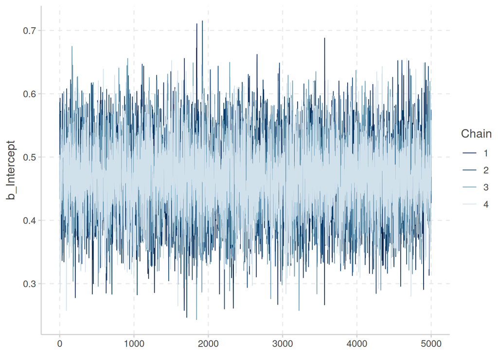

```r
# chain convergence
mcmc_plot(null,
         type = "trace",
         prob = 0.95)
```

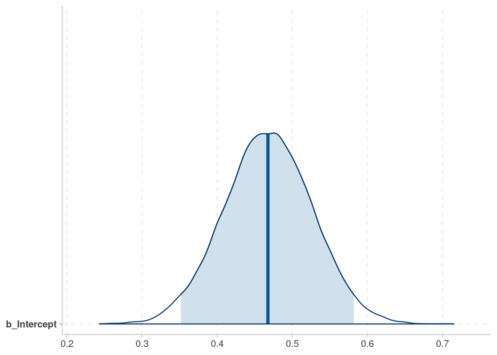

```r
# point estimate visualisation
mcmc_plot(null,
         type = "areas",
         prob = 0.95)
```

### Full Model

*Set-up*

```r
full <- brm(
  formula = overinformative ~ 1 + redundant + nDistract + setSize,
  data = tibble,
  family = bernoulli(link = "logit"), #binary logistic regression
  warmup = 5000,  #burn-in
  iter = 10000,  #samples
  chains = 4,  #n chains
  cores=4, # cpu cores running in parallel
  prior = prior("normal(0, 2)", class = "b"),
  seed = 3000, #seed so we can return
  save_pars = save_pars(all = TRUE)
  )
```

*Summary*

```r
summary(full)
```

```
 Family: bernoulli
  Links: mu = logit
Formula: overinformative ~ 1 + redundant + nDistract + setSize
   Data: tibble (Number of observations: 1205)
  Draws: 4 chains, each with iter = 10000; warmup = 5000; thin = 1;
         total post-warmup draws = 20000

Regression Coefficients:
                              Estimate Est.Error l-95% CI u-95% CI Rhat
Intercept                         0.88      0.21     0.46     1.30 1.00
redundantorientationredundant    -1.22      0.12    -1.46    -0.98 1.00
nDistractdistractors1             0.05      0.21    -0.36     0.45 1.00
nDistractdistractors2            -0.08      0.25    -0.57     0.40 1.00
nDistractdistractors3            -0.04      0.24    -0.52     0.43 1.00
nDistractdistractors4            -0.12      0.24    -0.60     0.36 1.00
setSizesetsize06                  0.23      0.23    -0.22     0.67 1.00
setSizesetsize09                  0.34      0.23    -0.12     0.79 1.00
setSizesetsize16                  0.39      0.23    -0.07     0.85 1.00
                              Bulk_ESS Tail_ESS
Intercept                        12008    13577
redundantorientationredundant    24692    14833
nDistractdistractors1            13008    12776
nDistractdistractors2            13325    15244
nDistractdistractors3            12641    14256
nDistractdistractors4            13078    14570
setSizesetsize06                 10892    13852
setSizesetsize09                 11034    14153
setSizesetsize16                 11976    14205

Draws were sampled using sampling(NUTS). For each parameter, Bulk_ESS
and Tail_ESS are effective sample size measures, and Rhat is the potential
scale reduction factor on split chains (at convergence, Rhat = 1).
```

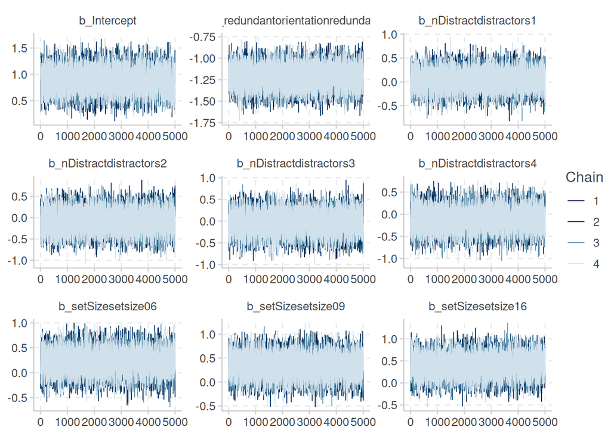

```r
# chain convergence
mcmc_plot(full,
         type = "trace",
         prob = 0.95)
```

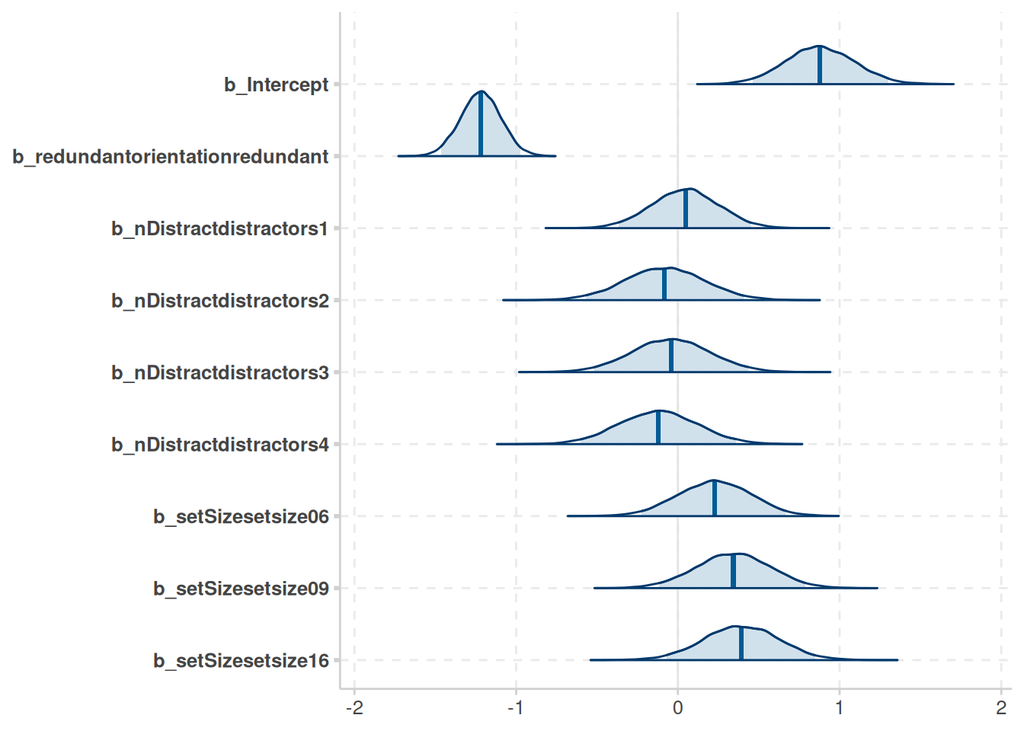

```r
# point estimate visualisation
mcmc_plot(full,
         type = "areas",
         prob = 0.95)
```

### Setsize + Attribute-redundant

*Set up*

```r
SetAtt  <- brm(
  formula = overinformative ~ 1 + redundant + setSize,
  data = tibble,
  family = bernoulli(link = "logit"), #binary logistic regression
  warmup = 5000,  #burn-in
  iter = 10000,  #samples
  chains = 4,  #n chains
  cores=4, # cpu cores running in parallel
  prior = prior("normal(0, 2)", class = "b"),
  seed = 3000, #seed so we can return
  save_pars = save_pars(all = TRUE)
  )
```

*Summary*

```r
summary(SetAtt)
```

```
 Family: bernoulli
  Links: mu = logit
Formula: overinformative ~ 1 + redundant + setSize
   Data: tibble (Number of observations: 1205)
  Draws: 4 chains, each with iter = 10000; warmup = 5000; thin = 1;
         total post-warmup draws = 20000

Regression Coefficients:
                              Estimate Est.Error l-95% CI u-95% CI Rhat
Intercept                         0.90      0.19     0.54     1.28 1.00
redundantorientationredundant    -1.21      0.13    -1.46    -0.97 1.00
setSizesetsize06                  0.16      0.21    -0.25     0.56 1.00
setSizesetsize09                  0.28      0.21    -0.13     0.68 1.00
setSizesetsize16                  0.37      0.21    -0.04     0.78 1.00
                              Bulk_ESS Tail_ESS
Intercept                         9978    11014
redundantorientationredundant    19014    14390
setSizesetsize06                  9515    11731
setSizesetsize09                  9933    11980
setSizesetsize16                  9881    12666

Draws were sampled using sampling(NUTS). For each parameter, Bulk_ESS
and Tail_ESS are effective sample size measures, and Rhat is the potential
scale reduction factor on split chains (at convergence, Rhat = 1).
```

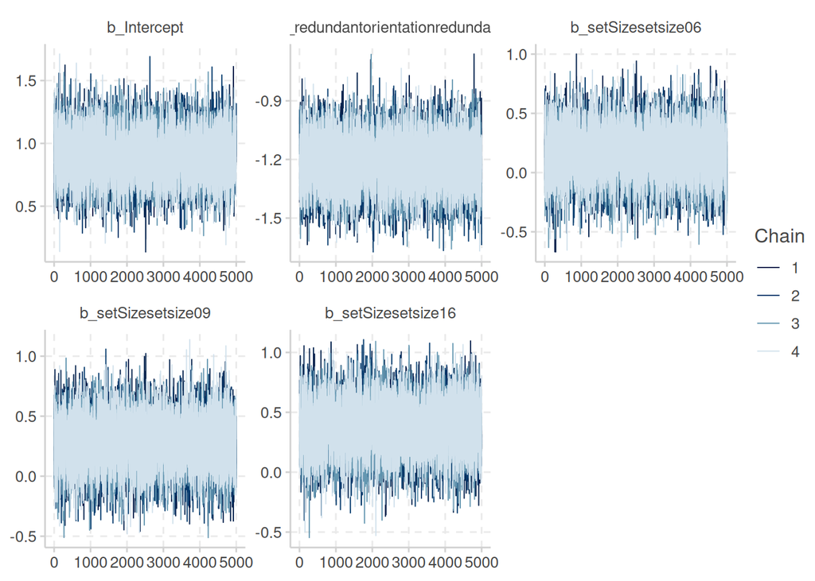

```r
# chain convergence
mcmc_plot(SetAtt,
         type = "trace",
         prob = 0.95)
```

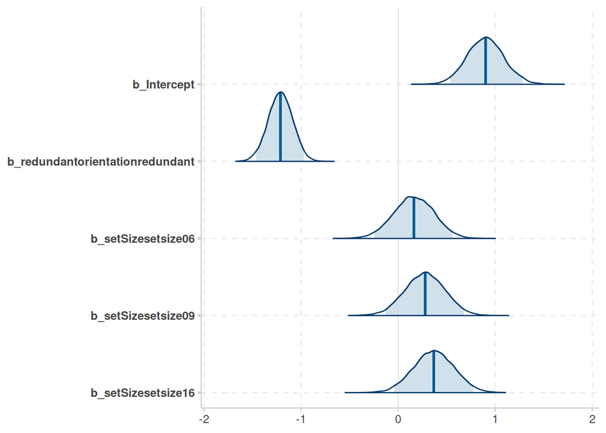

```r
# point estimate visualisation
mcmc_plot(SetAtt,
         type = "areas",
         prob = 0.95)
```

### N-distractors + Attribute-redundant

*Set up*

```r
DistAtt  <- brm(
  formula = overinformative ~ 1 + redundant + nDistract,
  data = tibble,
  family = bernoulli(link = "logit"), #binary logistic regression
  warmup = 5000,  #burn-in
  iter = 10000,  #samples
  chains = 4,  #n chains
  cores=4, # cpu cores running in parallel
  prior = prior("normal(0, 2)", class = "b"),
  seed = 3000, #seed so we can return
  save_pars = save_pars(all = TRUE)
  )
```

*Summary*

```r
summary(DistAtt)
```

```
 Family: bernoulli
  Links: mu = logit
Formula: overinformative ~ 1 + redundant + nDistract
   Data: tibble (Number of observations: 1205)
  Draws: 4 chains, each with iter = 10000; warmup = 5000; thin = 1;
         total post-warmup draws = 20000

Regression Coefficients:
                              Estimate Est.Error l-95% CI u-95% CI Rhat
Intercept                         1.19      0.12     0.96     1.42 1.00
redundantorientationredundant    -1.21      0.13    -1.46    -0.97 1.00
nDistractdistractors1            -0.08      0.17    -0.41     0.26 1.00
nDistractdistractors2            -0.11      0.20    -0.49     0.28 1.00
nDistractdistractors3            -0.07      0.20    -0.46     0.33 1.00
nDistractdistractors4            -0.15      0.20    -0.54     0.24 1.00
                              Bulk_ESS Tail_ESS
Intercept                        22305    15035
redundantorientationredundant    25377    16303
nDistractdistractors1            23455    15918
nDistractdistractors2            24123    16890
nDistractdistractors3            24252    17010
nDistractdistractors4            23731    15670

Draws were sampled using sampling(NUTS). For each parameter, Bulk_ESS
and Tail_ESS are effective sample size measures, and Rhat is the potential
scale reduction factor on split chains (at convergence, Rhat = 1).
```

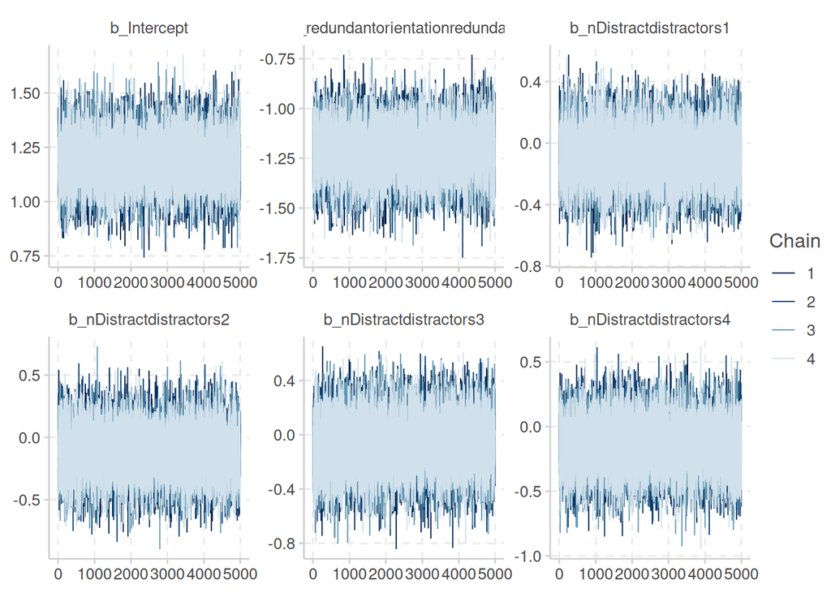

```r
# chain convergence
mcmc_plot(DistAtt,
         type = "trace",
         prob = 0.95)
```

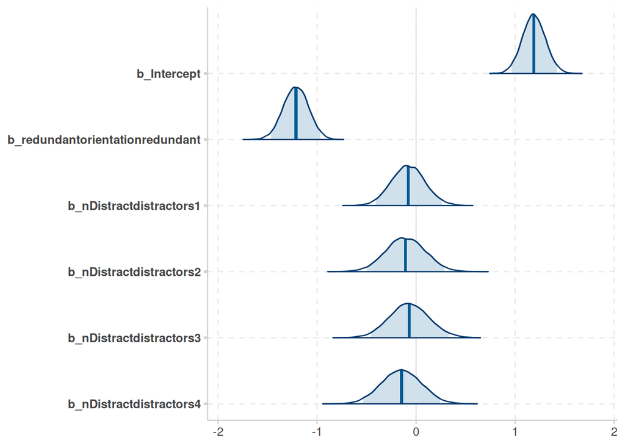

```r
# point estimate visualisation
mcmc_plot(DistAtt,
         type = "areas",
         prob = 0.95)
```

### Set Size

*Set up*

```r
setSize  <- brm(
  formula = overinformative ~ 1 + setSize,
  data = tibble,
  family = bernoulli(link = "logit"), #binary logistic regression
  warmup = 5000,  #burn-in
  iter = 10000,  #samples
  chains = 4,  #n chains
  cores=4, # cpu cores running in parallel
  prior = prior("normal(0, 2)", class = "b"),
  seed = 3000, #seed so we can return
  save_pars = save_pars(all = TRUE)
  )
```

*Summary*

```r
summary(setSize)
```

```
 Family: bernoulli
  Links: mu = logit
Formula: overinformative ~ 1 + setSize
   Data: tibble (Number of observations: 1205)
  Draws: 4 chains, each with iter = 10000; warmup = 5000; thin = 1;
         total post-warmup draws = 20000

Regression Coefficients:
                 Estimate Est.Error l-95% CI u-95% CI Rhat Bulk_ESS Tail_ESS
Intercept            0.24      0.17    -0.09     0.57 1.00     8279     9565
setSizesetsize06     0.17      0.20    -0.23     0.56 1.00     9181    11494
setSizesetsize09     0.27      0.20    -0.12     0.66 1.00     9072    10666
setSizesetsize16     0.36      0.20    -0.03     0.75 1.00     9303    11976

Draws were sampled using sampling(NUTS). For each parameter, Bulk_ESS
and Tail_ESS are effective sample size measures, and Rhat is the potential
scale reduction factor on split chains (at convergence, Rhat = 1).
```

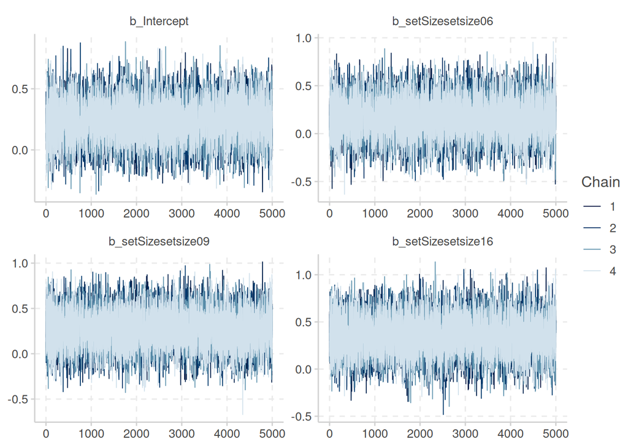

```r
# chain convergence
mcmc_plot(setSize,
         type = "trace",
         prob = 0.95)
```

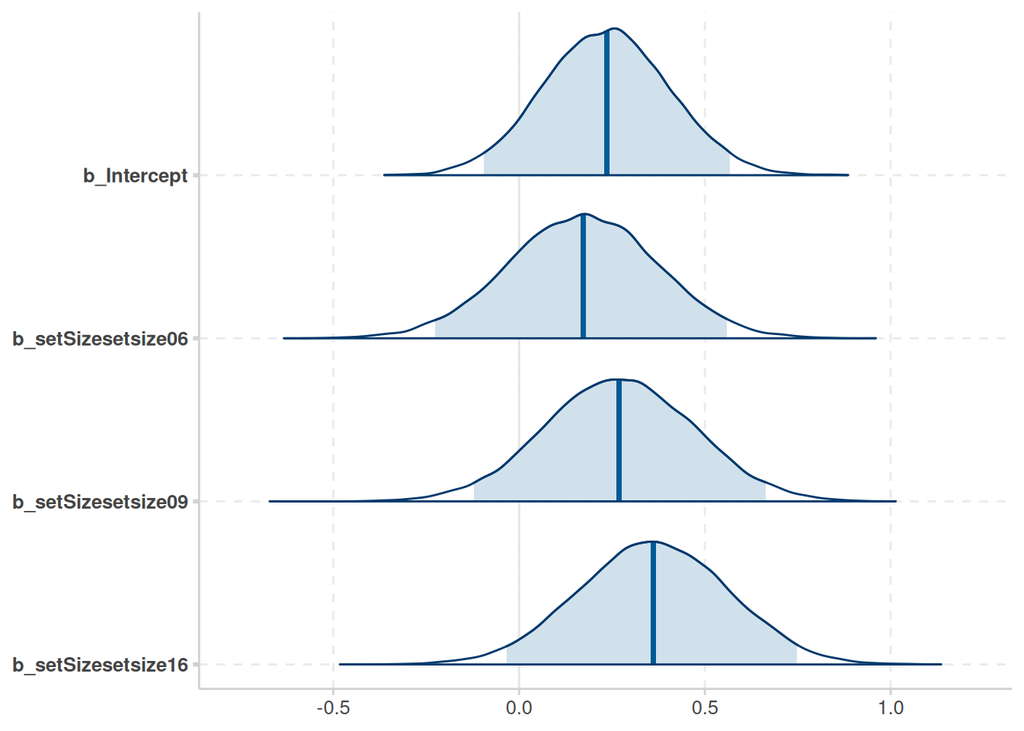

```r
# point estimate visualisation
mcmc_plot(setSize,
         type = "areas",
         prob = 0.95)
```

### N distractors

*Set up*

```r
nDistractor  <- brm(
  formula = overinformative ~ 1 + nDistract,
  data = tibble,
  family = bernoulli(link = "logit"), #binary logistic regression
  warmup = 5000,  #burn-in
  iter = 10000,  #samples
  chains = 4,  #n chains
  cores=4, # cpu cores running in parallel
  prior = prior("normal(0, 2)", class = "b"),
  seed = 3000, #seed so we can return
  save_pars = save_pars(all = TRUE)
  )
```

*Summary*

```r
summary(nDistractor)
```

```
 Family: bernoulli
  Links: mu = logit
Formula: overinformative ~ 1 + nDistract
   Data: tibble (Number of observations: 1205)
  Draws: 4 chains, each with iter = 10000; warmup = 5000; thin = 1;
         total post-warmup draws = 20000

Regression Coefficients:
                      Estimate Est.Error l-95% CI u-95% CI Rhat Bulk_ESS
Intercept                 0.52      0.09     0.35     0.69 1.00    16323
nDistractdistractors1    -0.08      0.17    -0.41     0.24 1.00    18557
nDistractdistractors2    -0.09      0.19    -0.46     0.28 1.00    19250
nDistractdistractors3    -0.06      0.19    -0.43     0.33 1.00    19680
nDistractdistractors4    -0.13      0.19    -0.51     0.25 1.00    19682
                      Tail_ESS
Intercept                14450
nDistractdistractors1    16235
nDistractdistractors2    15073
nDistractdistractors3    15186
nDistractdistractors4    16349

Draws were sampled using sampling(NUTS). For each parameter, Bulk_ESS
and Tail_ESS are effective sample size measures, and Rhat is the potential
scale reduction factor on split chains (at convergence, Rhat = 1).
```

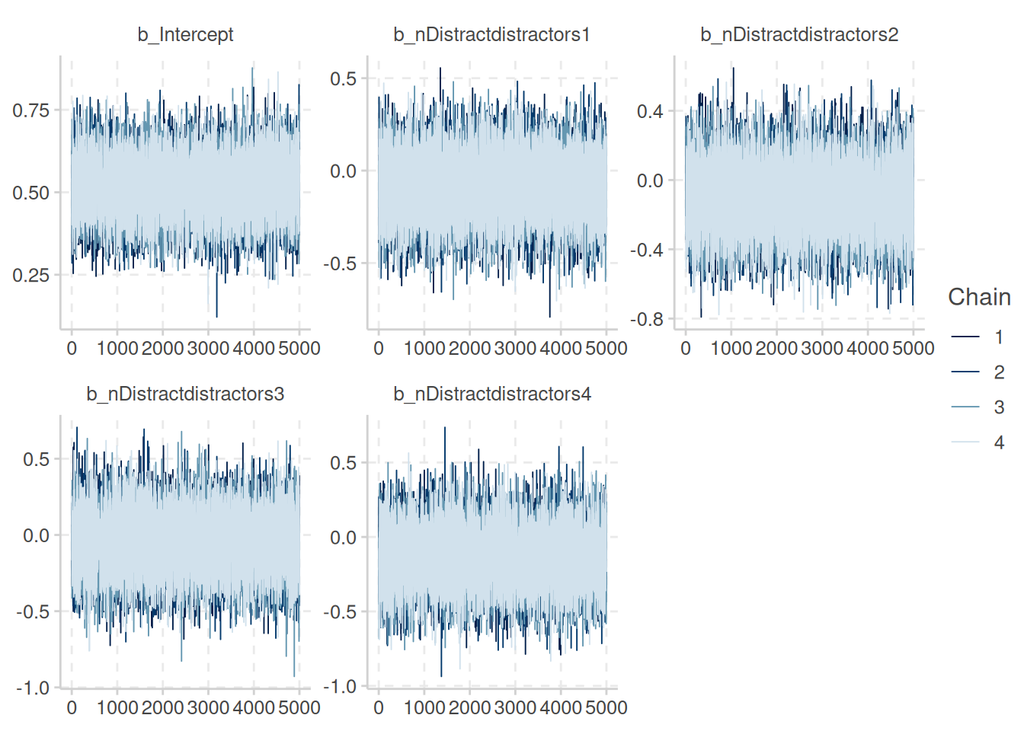

```r
# chain convergence
mcmc_plot(nDistractor,
         type = "trace",
         prob = 0.95)
```

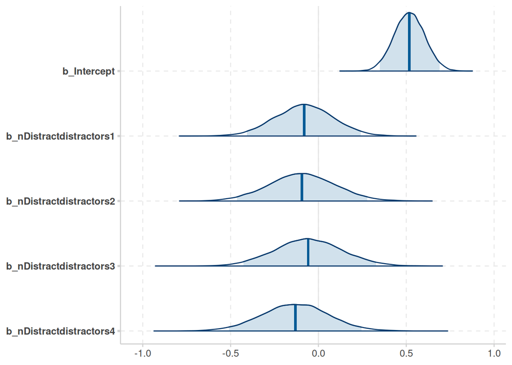

```r
# point estimate visualisation
mcmc_plot(nDistractor,
         type = "areas",
         prob = 0.95)
```

### Attribute Redundant

*Set up*

```r
attribute  <- brm(
  formula = overinformative ~ 1 + redundant,
  data = tibble,
  family = bernoulli(link = "logit"), #binary logistic  regression
  warmup = 5000,  #burn-in
  iter = 10000,  #samples
  chains = 4,  #n chains
  cores=4, # cpu cores running in parallel
  prior = prior("normal(0, 2)", class = "b"),
  seed = 3000, #seed for determinism
  save_pars = save_pars(all = TRUE)
  )
```

*Summary*

```r
summary(attribute)
```

```
 Family: bernoulli
  Links: mu = logit
Formula: overinformative ~ 1 + redundant
   Data: tibble (Number of observations: 1205)
  Draws: 4 chains, each with iter = 10000; warmup = 5000; thin = 1;
         total post-warmup draws = 20000

Regression Coefficients:
                              Estimate Est.Error l-95% CI u-95% CI Rhat
Intercept                         1.13      0.09     0.95     1.32 1.00
redundantorientationredundant    -1.21      0.12    -1.45    -0.97 1.00
                              Bulk_ESS Tail_ESS
Intercept                        14815    13265
redundantorientationredundant    16956    13674

Draws were sampled using sampling(NUTS). For each parameter, Bulk_ESS
and Tail_ESS are effective sample size measures, and Rhat is the potential
scale reduction factor on split chains (at convergence, Rhat = 1).
```

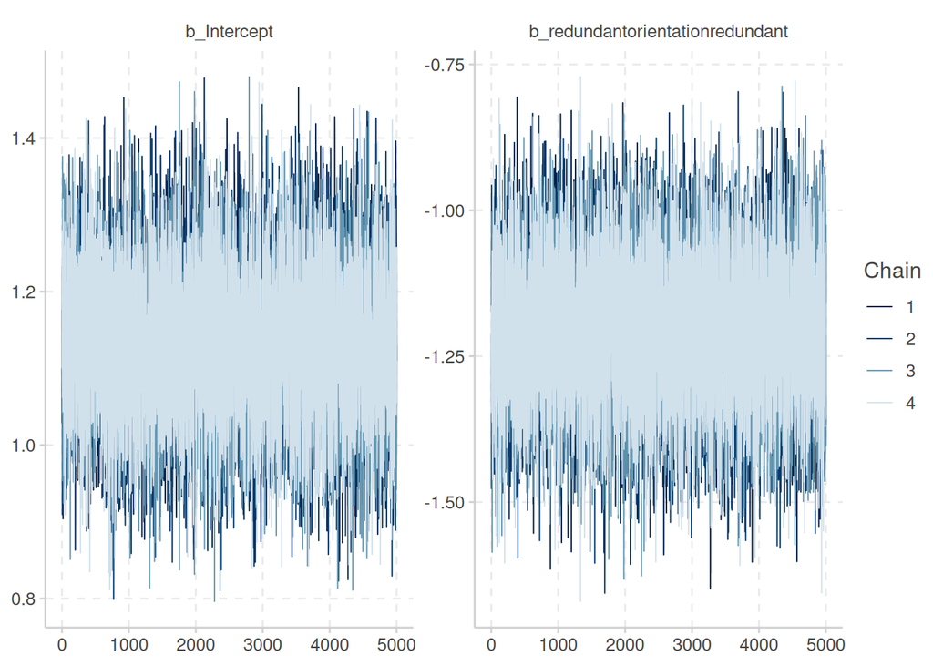

```r
# chain convergence
mcmc_plot(attribute,
         type = "trace",
         prob = 0.95)
```

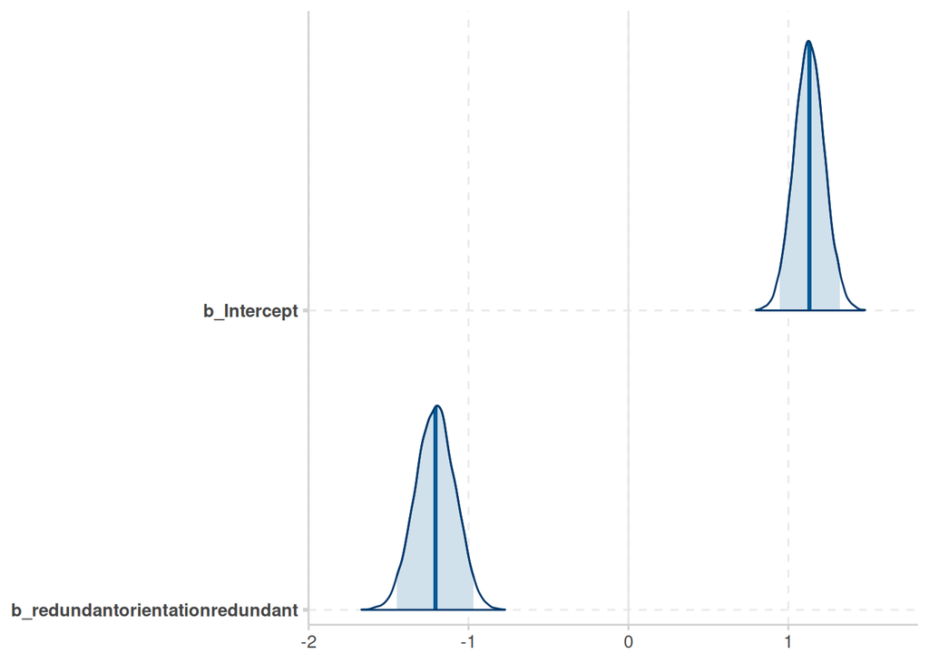

```r
# point estimate visualisation
mcmc_plot(attribute,
         type = "areas",
         prob = 0.95)
```

### Model Comparison

```r
bayes_factor(full, null, log = TRUE)
```

```
Iteration: 1
Iteration: 2
Iteration: 3
Iteration: 4
Iteration: 5
```

```
Iteration: 1
Iteration: 2
Iteration: 3
Iteration: 4
```

```
Estimated log Bayes factor in favor of full over null: 31.91666
```

```r
bayes_factor(DistAtt, null, log = TRUE)
```

```
Iteration: 1
Iteration: 2
Iteration: 3
Iteration: 4
```

```
Iteration: 1
Iteration: 2
Iteration: 3
Iteration: 4
```

```
Estimated log Bayes factor in favor of DistAtt over null: 37.29069
```

```r
bayes_factor(SetAtt, null, log = TRUE)
```

```
Iteration: 1
Iteration: 2
Iteration: 3
Iteration: 4
```

```
Iteration: 1
Iteration: 2
Iteration: 3
Iteration: 4
```

```
Estimated log Bayes factor in favor of SetAtt over null: 40.70931
```

```r
bayes_factor(setSize, null, log = TRUE)
```

```
Iteration: 1
Iteration: 2
Iteration: 3
Iteration: 4
```

```
Iteration: 1
Iteration: 2
Iteration: 3
Iteration: 4
```

```
Estimated log Bayes factor in favor of setSize over null: -5.79272
```

```r
bayes_factor(nDistractor, null, log = TRUE)
```

```
Iteration: 1
Iteration: 2
Iteration: 3
Iteration: 4
```

```
Iteration: 1
Iteration: 2
Iteration: 3
Iteration: 4
```

```
Estimated log Bayes factor in favor of nDistractor over null: -9.30587
```

```r
bayes_factor(attribute, null, log = TRUE)
```

```
Iteration: 1
Iteration: 2
Iteration: 3
Iteration: 4
```

```
Iteration: 1
Iteration: 2
Iteration: 3
Iteration: 4
```

```
Estimated log Bayes factor in favor of attribute over null: 46.39596
```